# Welcome to RStudio Cloud!

Author

Published

January 12, 2023

## Quarto

This is a Quarto document.

Quarto is a software that allows you to interweave text and R code to create HTML, PDF, and Microsoft Word documents

The document may look a bit different that you are used to, but we will break it down!

Section headers are defined with hashtags (#), where one # is the largest header, two ## is the second largest and so on.

You can make words boldface with two ** or two __ (like **so** or **so**).

You can make words italicized with one * or one _ (like *so* or *so*).

You can make lists like so:

- item 1
- item 2
- item 3

## R Code

You can differentiate the R code within a Quarto file from the body of the document, from the three tick marks (```) they start and end with.

Notice that after the ``` you see a curly brace with an “r” in it ({r}), this indicates to Quarto that the code inside of that code chunk is R code (not Python code or another type of code).

## Rendering

**Question 1:** Do you see the above code chunk when you knit the document? Why do you think this is the case?

## Including Code Output

You can include code output in your knitted document:

```r
glimpse(mpg)
```

```
Rows: 234
Columns: 11
$ manufacturer <chr> "audi", "audi", "audi", "audi", "audi", "audi", "audi", "…
$ model        <chr> "a4", "a4", "a4", "a4", "a4", "a4", "a4", "a4 quattro", "…
$ displ        <dbl> 1.8, 1.8, 2.0, 2.0, 2.8, 2.8, 3.1, 1.8, 1.8, 2.0, 2.0, 2.…
$ year         <int> 1999, 1999, 2008, 2008, 1999, 1999, 2008, 1999, 1999, 200…
$ cyl          <int> 4, 4, 4, 4, 6, 6, 6, 4, 4, 4, 4, 6, 6, 6, 6, 6, 6, 8, 8, …
$ trans        <chr> "auto(l5)", "manual(m5)", "manual(m6)", "auto(av)", "auto…
$ drv          <chr> "f", "f", "f", "f", "f", "f", "f", "4", "4", "4", "4", "4…
$ cty          <int> 18, 21, 20, 21, 16, 18, 18, 18, 16, 20, 19, 15, 17, 17, 1…
$ hwy          <int> 29, 29, 31, 30, 26, 26, 27, 26, 25, 28, 27, 25, 25, 25, 2…
$ fl           <chr> "p", "p", "p", "p", "p", "p", "p", "p", "p", "p", "p", "p…
$ class        <chr> "compact", "compact", "compact", "compact", "compact", "c…
```

**Question 2:** What do you think the above code does? What output does it give you?

## Including Plots

You can also embed plots in the knitted document.

Here is an example of a plot.

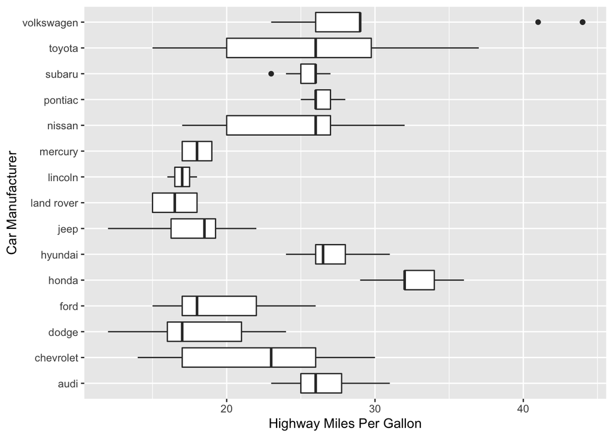